# Plotting Pie Chart

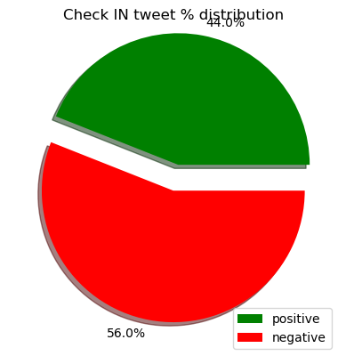

```python
import pandas as pd
import matplotlib.pyplot as plt
data=pd.read_csv("C:\\Users\\ASUS\\Downloads\\WEEK3 new\\WEEK3\\Immigration\\passport.csv")

count_positive = 0
count_negative = 0
count_neutral = 0

for sentiment in data['sentiment']:
    if sentiment == 'Positive':
        count_positive += 1
    else:
        count_negative += 1
total=len(data)
positive_response= (count_positive / total) * 100
negative_response = (count_negative / total) * 100
myexplode = [0.2, 0]
y=[positive_response,negative_response]
plt.pie(y,labels=[str(round(positive_response,2))+"%",str(round(negative_response,2))+"%"],explode = myexplode, shadow = True,colors=["g","r"])
plt.title("Check IN tweet % distribution")
plt.legend(["positive","negative"])
plt.show()
```

# LDA for positive tweets

```python
import pandas as pd
from sklearn.feature_extraction.text import CountVectorizer
from sklearn.decomposition import LatentDirichletAllocation

from sklearn.feature_extraction import text

# Read the positive reviews data
positive_reviews = pd.read_csv("C:\\Users\\ASUS\\Downloads\\WEEK3 new\\WEEK3\\Immigration\\passport - Copy.csv")

# Combine reviews into a list
reviews = positive_reviews['tweet'].tolist()

# Create a custom stop words list if needed
custom_stop_words = ["read", "good", "disney", "yorker", "day", "didn", "stay", "great", "check", "booked", "like", "die", "told", "friendly", "clean", "sehr", "das", "zimmer", "und", "nice", "did", "was", "really", "safe", "walk", "close", "got"]

# Extend the default English stop words list with custom stop words
stop_words = list(text.ENGLISH_STOP_WORDS) + custom_stop_words

# Vectorize the text data
vectorizer = CountVectorizer(max_df=0.95, min_df=2, stop_words=stop_words)
X = vectorizer.fit_transform(reviews)

# Apply LDA for topic modeling
num_topics = 5
lda = LatentDirichletAllocation(n_components=num_topics, random_state=42)
lda.fit(X)

# Extract top words for each topic
feature_names = vectorizer.get_feature_names_out()
topics = []
for topic_idx, topic in enumerate(lda.components_):
    top_words_idx = topic.argsort()[-10:]
    top_words = [feature_names[i] for i in top_words_idx]
    topics.append(top_words)

# Print the top words for each topic (possible reasons for positive reviews)
for i, topic in enumerate(topics):
    print(f"Topic {i + 1}: {', '.join(topic)}")
```

```
Topic 1: years, months, days, 30, need, travel, validity, thailand, wife, indian
Topic 2: traveling, ticket, driver, home, seen, rpo, today, left, thanks, help
Topic 3: valid, number, buy, officers, shop, free, duty, rpo, help, immigration
Topic 4: visited, customs, mumbai, best, india, asked, lost, hand, officer, look
Topic 5: nightmare, years, need, quite, checked, card, amp, pass, boarding, security
```

# Observation on positive tweet

- ### There are many government officials and airport staff who are helpful and accommodating to travelers.
- ### Visa-free arrangements between countries make it easier for people to travel.
- ### Duty-free shops and other businesses are offering valuable services to travelers.

## Recommendations:

- ### Government agencies and businesses should continue to provide excellent customer service to travelers.
- ### Visa-free arrangements should be expanded to more countries.
- ### More businesses should offer services to help travelers, such as RPO assistance and lost passport assistance.

# Word Cloud for positive tweets

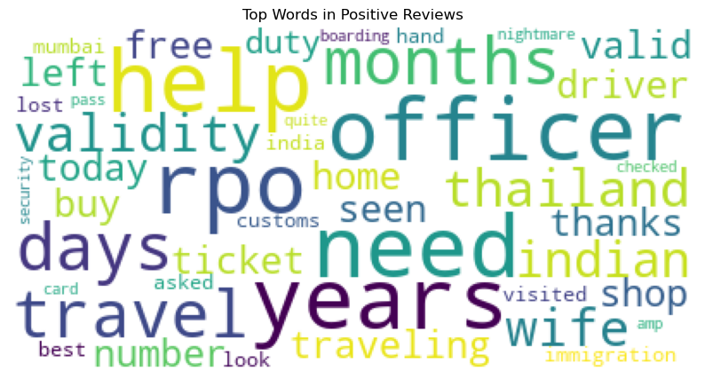

```python
import matplotlib.pyplot as plt
from wordcloud import WordCloud

# Create a word cloud object
wc = WordCloud(background_color="white", max_font_size=50)

# Check the type of the topics variable
if isinstance(topics, list):
    # Convert the topics variable to a list of strings
    topics = [" ".join(topic) for topic in topics]

# Generate the word cloud
wc.generate(" ".join(topics))

# Plot the word cloud
plt.figure(figsize=(10, 10))
plt.imshow(wc)
plt.axis("off")
plt.title("Top Words in Positive Reviews")
plt.show()
```

# LDA for Negative tweets

```python
import pandas as pd
from sklearn.feature_extraction.text import CountVectorizer
from sklearn.decomposition import LatentDirichletAllocation
from sklearn.feature_extraction import text

# Read the negative reviews data
negative_reviews = pd.read_csv("C:\\Users\\ASUS\\Downloads\\WEEK3 new\\WEEK3\\Immigration\\passport - Copy (2).csv")

# Combine reviews into a list
reviews = negative_reviews['tweet'].tolist()

# Create a custom stop words list if needed
custom_stop_words = ["read", "good", "disney", "yorker", "day", "didn", "stay", "great", "check", "booked", "like", "die", "told", "friendly", "clean", "sehr", "das", "zimmer", "und", "nice", "did", "was", "really", "safe", "walk", "close", "got"]

# Convert the custom stop words to a list
custom_stop_words = list(custom_stop_words)

# Extend the default English stop words list with custom stop words
stop_words = list(text.ENGLISH_STOP_WORDS) + custom_stop_words

# Vectorize the text data
vectorizer = CountVectorizer(max_df=0.95, min_df=2, stop_words=stop_words)
X = vectorizer.fit_transform(reviews)

# Apply LDA for topic modeling
num_topics = 5
lda = LatentDirichletAllocation(n_components=num_topics, random_state=42)
lda.fit(X)

# Extract top words for each topic
feature_names = vectorizer.get_feature_names_out()
topics = []
for topic_idx, topic in enumerate(lda.components_):
    top_words_idx = topic.argsort()[-10:]
    top_words = [feature_names[i] for i in top_words_idx]
    topics.append(top_words)

# Print the top words for each topic (possible reasons for negative reviews)
for i, topic in enumerate(topics):
    print(f"Topic {i + 1}: {', '.join(topic)}")
```

```
Topic 1: indian, ago, control, month, authority, immigration, officer, allowed, asked, stamp
Topic 2: provided, status, details, madam, pls, ago, copy, son, aadhar, control
Topic 3: indian, counter, stuck, fake, long, delhi, authority, time, impounded, immigration
Topic 4: 30, indian, immigration, officer, india, security, holder, visa, today, travel
Topic 5: specifically, order, list, leaving, exit, control, court, stopped, india, trip
```

# Observation on negative tweet

- ### The immigration authorities are not adequately enforcing visa regulations.
- ### The immigration authorities are asking passengers to provide unnecessary documents.
- ### The immigration authorities are not adequately trained to recognize valid visas and court orders.
- ### The immigration authorities are not providing adequate assistance to passengers who have problems with their visas or passports.

## Recommendations:

- ### The immigration authorities should tighten their controls to prevent overstayers and fake passports from entering the country.
- ### The immigration authorities should review their procedures to ensure that passengers are not asked to provide unnecessary documents.
- ### The immigration authorities should train their officers on visa regulations, court orders, and customer service.
- ### The immigration authorities should provide more assistance to passengers who have problems with their visas or passports.

# Word Cloud for negative tweets

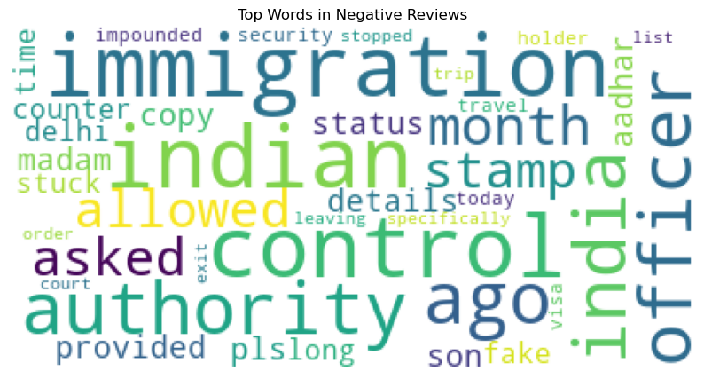

```python
import matplotlib.pyplot as plt
from wordcloud import WordCloud

# Create a word cloud object
wc = WordCloud(background_color="white", max_font_size=50)

# Check the type of the topics variable
if isinstance(topics, list):
    # Convert the topics variable to a list of strings
    topics = [" ".join(topic) for topic in topics]

# Generate the word cloud
wc.generate(" ".join(topics))

# Plot the word cloud
plt.figure(figsize=(10, 10))
plt.imshow(wc)
plt.axis("off")
plt.title("Top Words in Negative Reviews")
plt.show()
```